# Science des données I : module 2

Git et Github

Philippe Grosjean & Guyliann Engels

# Git et Github

## Qu’est-ce que Git ?

### Pourquoi gérer des versions ?

[figure not shown]

### Pourquoi gérer des versions ?

[figure not shown]

### Qu’est-ce que Git ?

**Git est un système de gestion de versions**

- A un moment donné, on ne voit qu’une seule version
- Mais *toutes* les versions sont sauvegardées
- On, peut revenir à n’importe quelle de ces versions à tout moment
- On peut naviguer dans l’historique et voir les différences d’une version à l’autre
- Enregistrer une version se dit **faire un commit** dans le langage de Git

### Gestion de l’historique dans Github Desktop

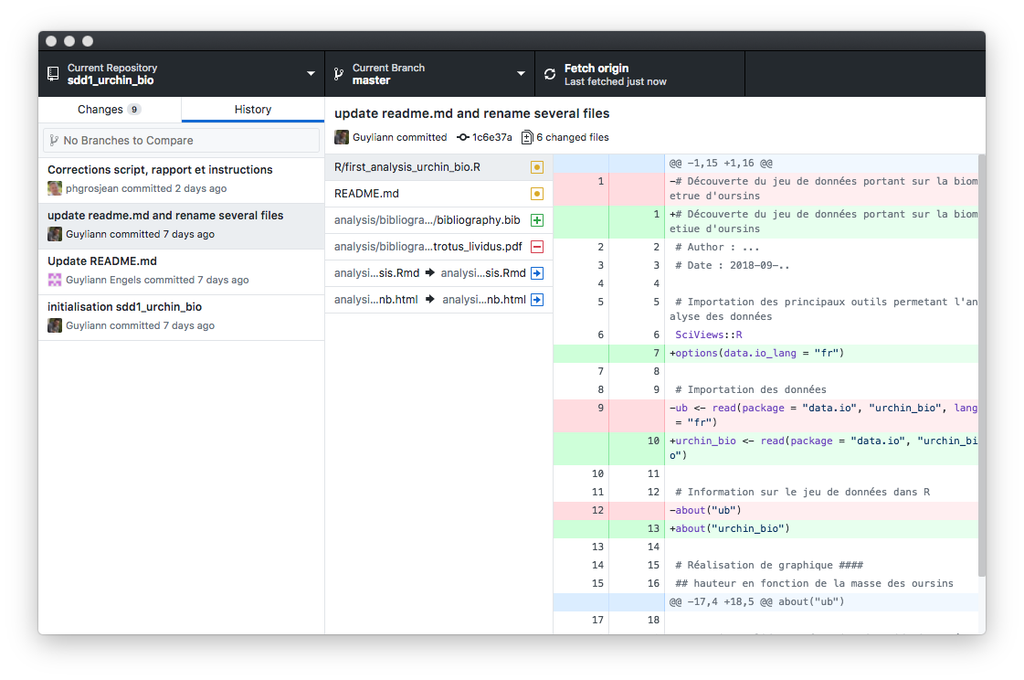

### Comment faire dans RStudio ?

- Créer ou ouvrir un **projet** dans **RStudio** et **activer Git**
- Un onglet **Git apparait**. Tout peut être fait directement à partir de là
- Sélectionner les fichiers modifiés à committer
- Effectuer un **commit** à chaque fois qu’on veut enregistrer un état, et indiquer un message explicite

**Démonstration “en live”**

## Qu’est-ce que Github ?

### Sauvegarder sur le Net et partager ses projets

- Le “cloud” a beaucoup de succès. De nombreuses solutions existent : Google Drive/Docs, One Drive, iCloud, Dropbox, …
- Github, Gitlab, ou Bitbucket (entre autres) proposent de combiner le partage en ligne avec la gestion de version Git

[figure not shown]

### “Forker” un projet Github dans son espace et l’utiliser sur son PC

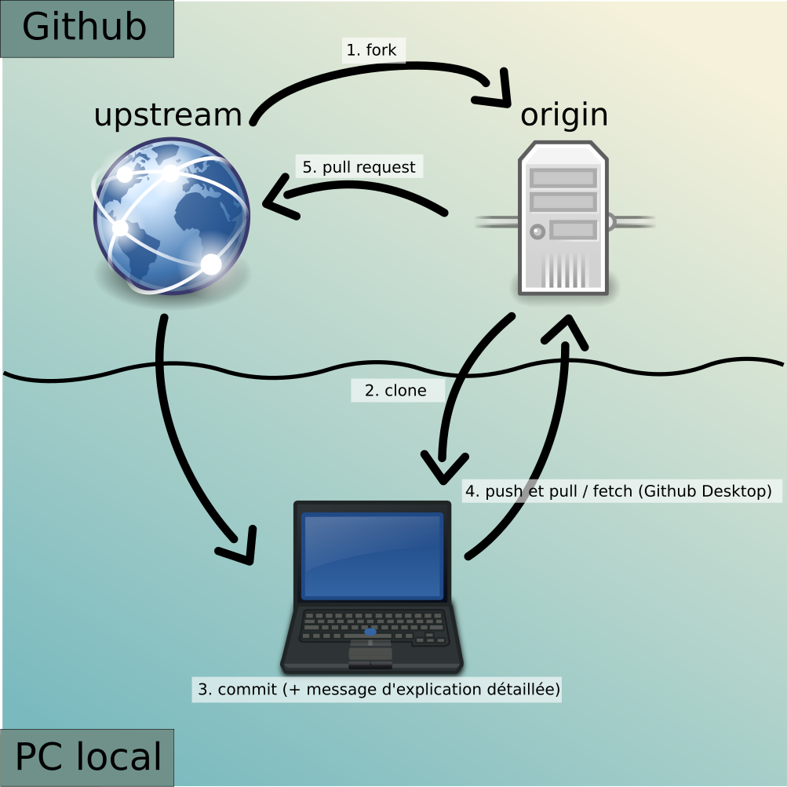

### A vous de jouer !

Mettez tout cela en application en réalisant votre propre site web à partir d’un fork de `BioDataScience-Course/blogdown.source`